# Perception for Scientific Visualization

Steve Elston

09/04/2023

# Why This Course?

21st Century datasets are large and complex

- Complexity is often harder to address than size
- Complexity makes understanding of relationships in data difficult
- Complexity addressed with computer-intensive methods
- Our focus is on the big ideas of computer-intensive statistics and data analysis arising in the late 20th and early 21st Centuries

# Why This Course?

**Data science** is the science of **understanding data**

- Complexity makes understanding difficult
- Statistics is the science of making **principled inferences** from data
  - Inference leads to understanding
  - Inference is becoming harder with large complex data sets
- Doing rigorous data science requires understanding statistics
  - Statistical practice has advanced significantly to address large complex data sets
  - Statistical practice now dominated by computer-intensive methods

# What We’ll Cover

Our focus is on the big ideas of computer-intensive statistics and data analysis arising in the late 20th and early 21st Centuries

- **Exploratory data analysis (EDA)** to understand relationships in big complex data sets
- **Foundations of algorithms** used throughout statistics and machine learning such as maximum likelihood
- **Computer intensive resampling methods** for building models and inference, **Bootstrapping** and **MCMC Bayes**
- **Large scale and sparse models** for complex and high-dimensional data sets
- **Non-Normal** response models
- **Bayesian hierarchical models** for complex relationships
- **Modern time series and forecasting algorithms** for data with serial correlation
- **Robust statistics** to deal with data violating model assumptions

# Course Objectives

This fast-moving survey course helps build your toolbox for modeling complex data

- Broad introduction to the theoretical and methodological basis of data science
  - Conditional probability theory
  - Sampling theory
  - Statistical estimation theory - classical and resampling based
- Understand models for complex datasets
  - Understanding data relationships and inference
  - How these methods work and when to used them
  - How confident should we be in our inferences?
- Moving beyond a cookbook or blog post approach to data science

# Instructor: Steve Elston

- Data science consultant with several decades of experience
- Instructor for Harvard since 2016
- Lead team that commercialized Bell Labs S, now open source R
- Company co-founder and held executive positions in several industries
- Creator of multiple edX courses, author of O’Reily books and articles
- Holder of 5 issued patents
- BS, physics and math (minor), University of New Mexico
- MS and PhD, geophysics, Princeton University – NSF, John von Neuman Supercomputing Fellow

# Teaching Assistant: Moustafa Saleh

- A principal data scientist at Oracle Cloud
- Received PhD in computer science from University of Texas at San Antonio
- Worked previously at Microsoft’s Advanced Threats Protection team developing ML solutions for malware detection
- Research mainly focused on applying machine learning solutions to cyber-security challenges

# Teaching Assistant: Tatyana Boland

- MBA in Finance from Texas A&M
- MLA from Harvard Extension School in Sustainability & Environmental Management
- BA in Political Science from University of Washington
- Worked previously at Oracle OCI as Principal Technical Program Manager in Physical Networking team

# Grading: Undergraduate

| Activity | Grade weight |
| --- | --- |
| Participation (graded discussions) | 10% |
| Assignments | 90% |

- Hands-on assignments tie theory to practice applied to data examples
  - Most of us only recall methods we actually use
  - Lectures provide introduction only
  - Expect to work out some details
  - Do not hesitate to ask for help on concepts or coding!!

# Grading: Graduate

| Activity | Grade weight |
| --- | --- |
| Participation (graded discussions) | 10% |
| Assignments | 60% |
| Independent project proposal | 5% |
| Independent project report | 25% |

- Hands-on assignments tie theory to practice applied to data examples
  - Most of us only recall methods we actaully use
  - Lectures provide introduction only
  - Expect to work out some details
  - Do not hesitate to ask for help on concepts or coding!!
- You will execute an end-to-end project on an appropriate problem of you choice

# Grading: Graduate

Independent Graduate Project:

- An end-to-end project you will execute independently
- Pay careful attention to grading rubric in Canvas
- Can be great addition to your data science project portfolio
- Pick a problem of particular interest to you!
  - Plan to spend about 80 hours on your analysis and report
  - Sufficient data must be available
  - **Must use analytical methods within the scope of this course** - e.g. no advanced ML or deep learning
- Start thinking about your project soon - don’t put it off
- Resources to help you get started are under the **Resources tab in Ed Discussion**
  - List of possible data sources: Far from comprehensive
  - Example project proposals and reports

# Late Assignment Policy

- Timely feedback is an important part of the learning process
- To allow the timely release of solutions for assignments this course applied a late assignment policy:
  - Up to one day late - no penalty
  - Up to 6 days late - less 20%
  - More than 6 days late - no credit

**Advice:** start assignments and your project as soon as you can so you have time to address problems and ask questions!

**Note: No extension is possible for Graduate Independent Projects!**

# Class Schedule

- Class meeting Tuesdays, 6:00 pm US Eastern Time:
  - Focus on theory to understand concepts
  - Limited time for code discussions
- Section meetings **day TBD**, 6:00 pm US Eastern Time:
  - Focus on answer student questions - your questions!
  - Discus code and coding problems
  - Background and supplementary material as needed
  - Poll to find best day for class
- All class meetings are recorded for on-demand viewing

# Communications

Communicating with your instructors and other students is a significant aspect of participation in this course!

- Ask questions about the course material, homework, etc.
- Ask questions in the public forum so others can answer and gain from the discussion: if you have a question others do as well!
- Answer other students’ questions
- Comment on weekly graded discussion topics

**Ed is the primary communications method**  
- Generally use public posts - okay to include code snippets  
- Option to ask instructors private questions

**Ask for the help you need!**

Any communications by Canvas will likely be delayed

# Communications

For private matters, you can directly communicate with the instructional team:  
- Grades  
- Absences  
- Etc

Steve Elston, Instructor, stephen.elston gmail.com  
Moustafa Saleh, TA, msaleh83 gmail.com  
Tatyana Boland, TA, tatyanaboland gmail.com

**Office hours:** If you need individual assistance, please ask to schedule office hours. Don’t be shy!

Communications by Canvas may be **significantly delayed!**

# Poll

Then, back to the lecture

# Why Exploration and Visualization?

**Exploratory data analysis (EDA)** tools are essential to good data science

- Isn’t the goal of data science to build machine learning models?
- Not always!
- Often we need to understand relationships found in data
  - Explain scientific or behavioral relationships
  - Determine if a relationship is important
- Our goal is to gain deep understanding for complex problem
  - EDA methods
  - Statistical inference

# Why Exploration and Visualization?

**Exploratory data analysis (EDA)** tools are essential to good data science

- Why not just start building machine learning models?
- Understanding relationships in data saves missteps and unexplained poor model performance
  - Which variables are actually important?
  - How do these variables behave?
  - Are there errors and outliers in the data?
  - How good is a model fit?
- Communications is an important component of data science
  - Analytic results are only useful if they are understood and trusted
  - Graphical presentation greatly assists understanding by less technical colleagues

# Why is Perception Important?

- **Goal:** Communicate information visually
- Visualization technique maximize the information a viewer perceives
  - Gain insights when exploring relationships in data
  - Communicate insights to others
- Limits of human perception are a significant factor in understanding complex relationships
- Can apply results of the considerable research on human perceptions for data visualization

# Use Aesthetics to Improve Perception

- Use aesthetics to improve perception
- We take a very broad view of the term ‘aesthetic’ here
- A plot aesthetics is any property of a visualization which highlight aspects of the data relationships
- Aesthetics are used to project additional dimensions of complex data
  - Plots generally restricted to 2-dimensional surface
  - Must projet multiple dimensions of complex data on 2-d surface

# Organization of Plot Aesthetics

We can organize aesthetics by their effectiveness:

1. **Easy to perceive plot aesthetics:** help most people gain understanding of data relationships
2. **Aesthetics with moderate perceptive power:** useful properties to project data relationships when used sparingly
3. **Aesthetics with limited perceptive power:** useful within strict limits

# Properties of Common Aesthetics

| Property or Aesthetic | Perception | Data Types |
| --- | --- | --- |
| Aspect ratio | Good | Numeric |
| Regression lines | Good | Numeric plus categorical |
| Marker position | Good | Numeric |
| Bar length | Good | Counts, numeric |
| Sequential color palette | Moderate | Numeric, ordered categorical |
| Marker size | Moderate | Numeric, ordered categorical |
| Line types | Limited | Categorical |
| Qualitative color palette | Limited | Categorical |
| Marker shape | Limited | Categorical |
| Area | Limited | Numeric or categorical |
| Angle | Limited | Numeric |

# Aspect Ratio

- **Aspect ratio** has a significant influence on how a viewer perceives a chart
- Correct aspect ratio can help highlight important relationships in complex data sets
- But, wrong aspect ratio can hide or mislead!
- We express aspect ratio as follows:

$$aspect\ ratio = \frac{width}{height}\ :
1$$

- **Banking angle** is key to understanding how the aspect ratio affects perception
  - Humans are most sensitive to changes about 45 degrees
  - Optimal banking angle controlled by aspect ratio

# Example of Changing Aspect Ratio

Longest scientific time series is the sunspot count:

```
##      YEAR  SUNACTIVITY
## 0  1700.0          5.0
## 1  1701.0         11.0
## 2  1702.0         16.0
## 3  1703.0         23.0
## 4  1704.0         36.0
```

# Example of Changing Aspect Ratio

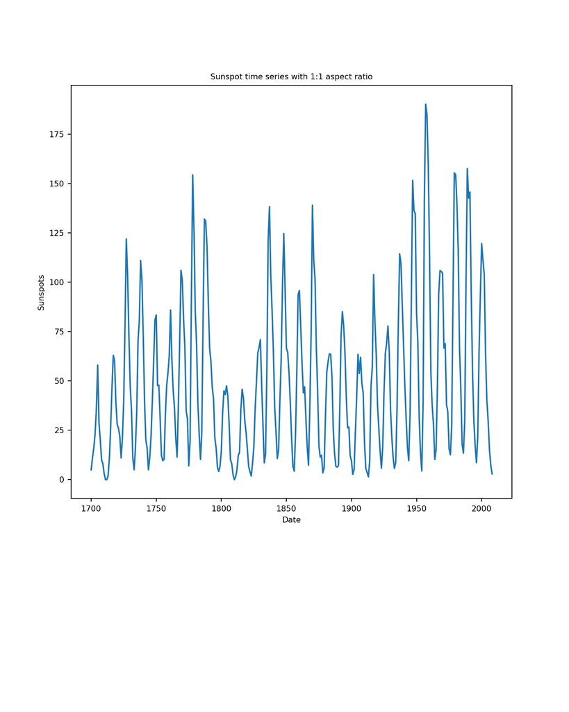

# Example of Changing Aspect Ratio

- Notice how changing aspect ratio change perception of the asymmetry?
- Banking angle is near optimal

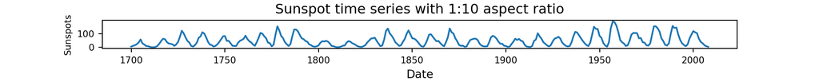

# Sequential and Divergent Color Palettes

Use of **color** as an aesthetic in visualization is a complicated subject.

- color is often used, also often abused
- A **qualitative palette** is a palette of individual colors for categorical values
- **Sequential palettes** and **divergent palettes** are a sequence of colors
  - Numeric variables
  - Ordered categorical variable

# Auto Weight by Sequential Color Palette

```python
fig, ax = plt.subplots(figsize=(8,10))
fig.subplots_adjust(top=0.8, bottom=0.2)
ax = sns.scatterplot(x='city_mpg', y='curb_weight', data=auto_price,
                     hue = 'price', palette = 'magma', ax=ax)
_=ax.set_title('City MPG vs. Weight \nPrice by color') #, fontsize=12)
_=ax.set_xlabel('City MPG') # , fontsize=12)
_=ax.set_ylabel('Vehicle Weight') #, fontsize=12)
plt.show()
```

# Auto Weight by Sequential Color Palette

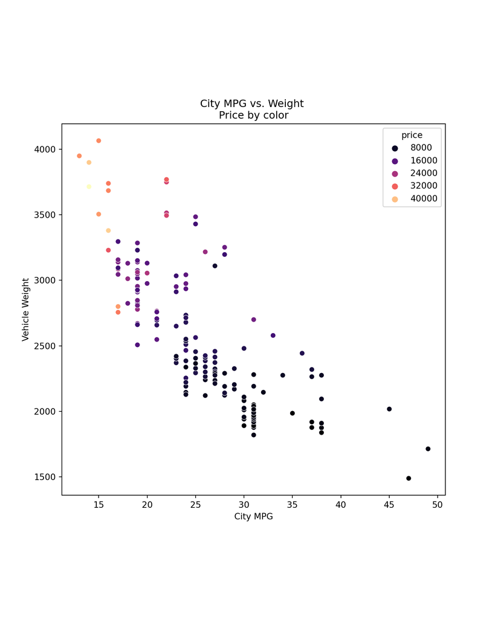

# Limits of color

Regardless of the approach there are some significant limitations

- A significant number of people are color blind. Red-green color blindness is most common
- Even the best sequential or divergent palettes show only relative value of numeric variables
- Perception of exact numeric values is difficult, except in special cases
- Cannot perceive large number of colors for categories

# Marker Size

**Marker size** is moderately effective aesthetic

- Used properly, marker size can highlight important realationships in complex data sets
  - Numeric values
  - Ordinal variables
- Viewers can generally perceive relative differences, but not actual values
- Small size differences are not preceptable
  - Only relative relationship in numeric variables
  - Limited steps of categorical variables

# Engine Size by Marker Size and Price by Sequential Color Palette

```python
fig, ax = plt.subplots(figsize=(8,7))
ax = sns.scatterplot(x='city_mpg', y='curb_weight', data=auto_price,
                     hue = 'price', palette = 'magma',
                     size = 'engine_size', sizes = (50.0, 400.0),
                     ax=ax)
_=ax.set_title('City MPG vs. Weight \nPrice by color, engine size by size') #, fontsize=18)
_=ax.set_xlabel('City MPG') #, fontsize=16)
_=ax.set_ylabel('Vehicle Weight')# , fontsize=16)
plt.show()
```

# Engine Size by Marker Size and Price by Sequential Color Palette

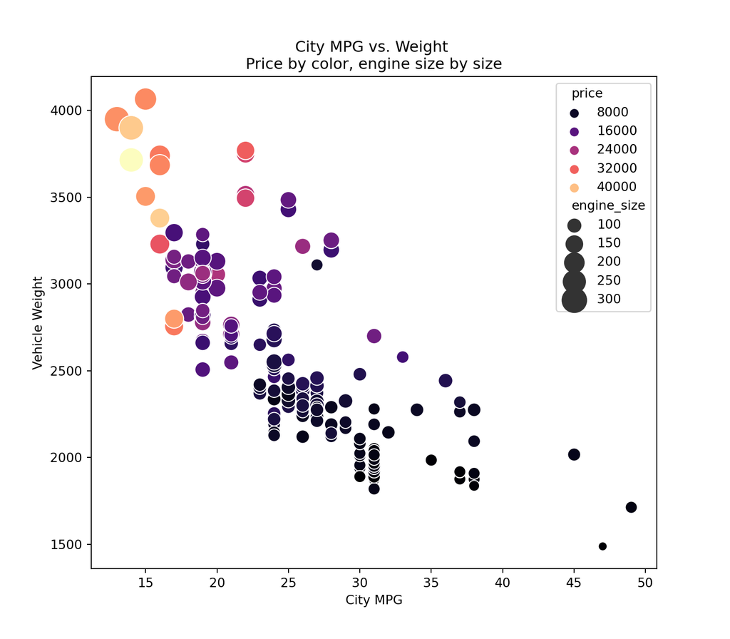

# Line Plots and Line Type

**Line plots** connect discrete, ordered, data points by a line

- Can use different colors and line pattern types to differentiate categories
- Only useful for a limited number of lines on one graph
- Too many similar colors and line patterns on one plot leads to viewer confusion and poor perception

# Limits of Line Type

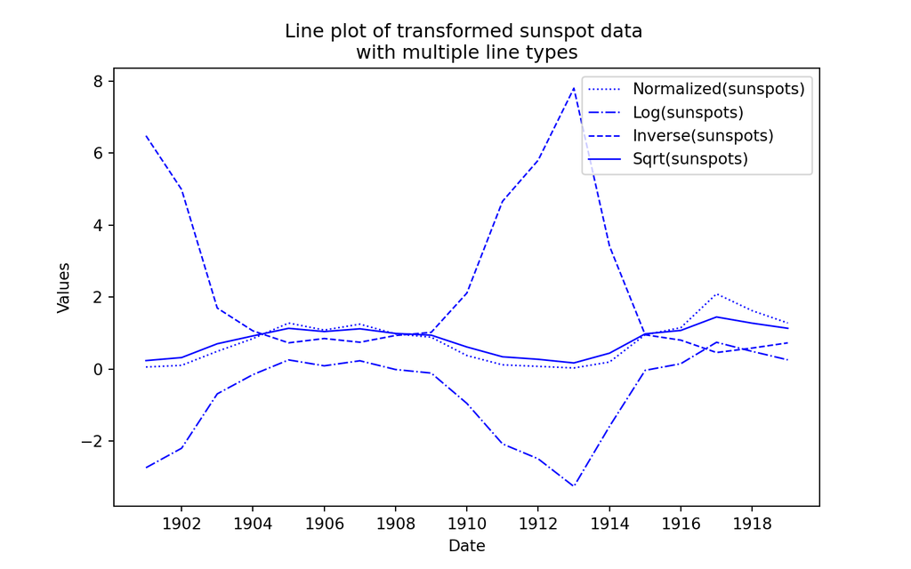

# Marker Shape

**Marker shape** is useful for displaying categorical relationships

- This aesthetic is only useful when two conditions are met:
1. The number of categories is small
2. Distinctive shape are chosen for the markers
- Human perception limits the number of shapes humans can perceive well

# Aspiration by Marker Shape

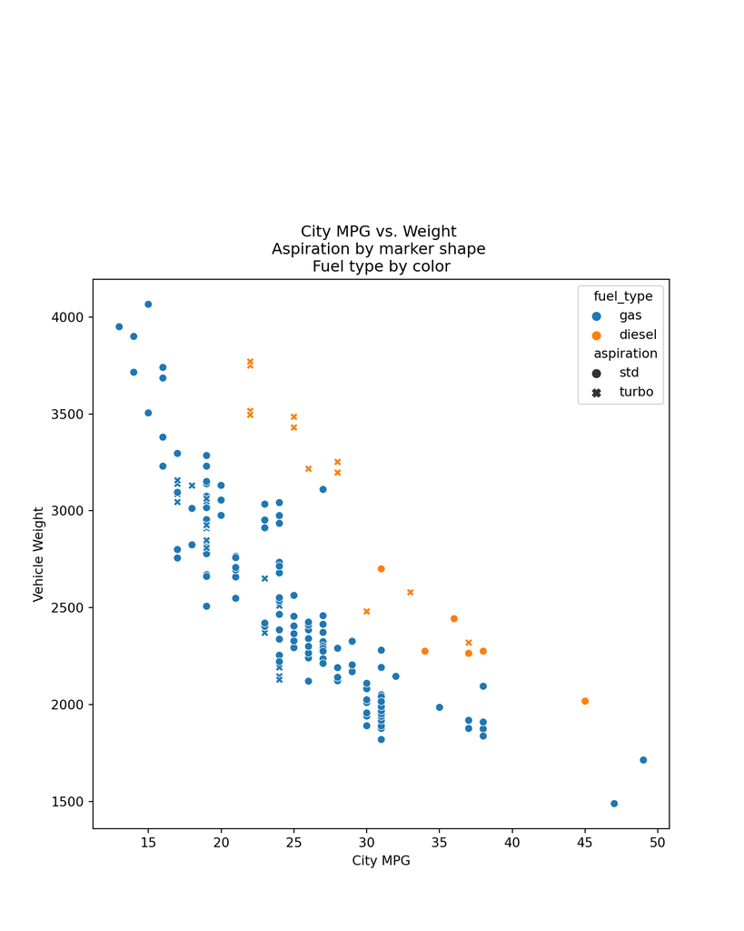

# Regression Lines

Regression lines draw viewers attention

- Typically use a nonlinear regression line
  - Polynomial
  - Splines - piece wise model
  - Lowess - local nonlinear regression
- Bootstrap confidence intervals show range of probable trends
  - More about bootstrap resampling later
- Ideally want strait line relationship
  - Nonlinear relationships often arise from non-Normal distributions
  - Linear relationship is more intuitive

# Regression Line and Tramsformation Example

Regression lines highlight the trends for gas and diesel engines

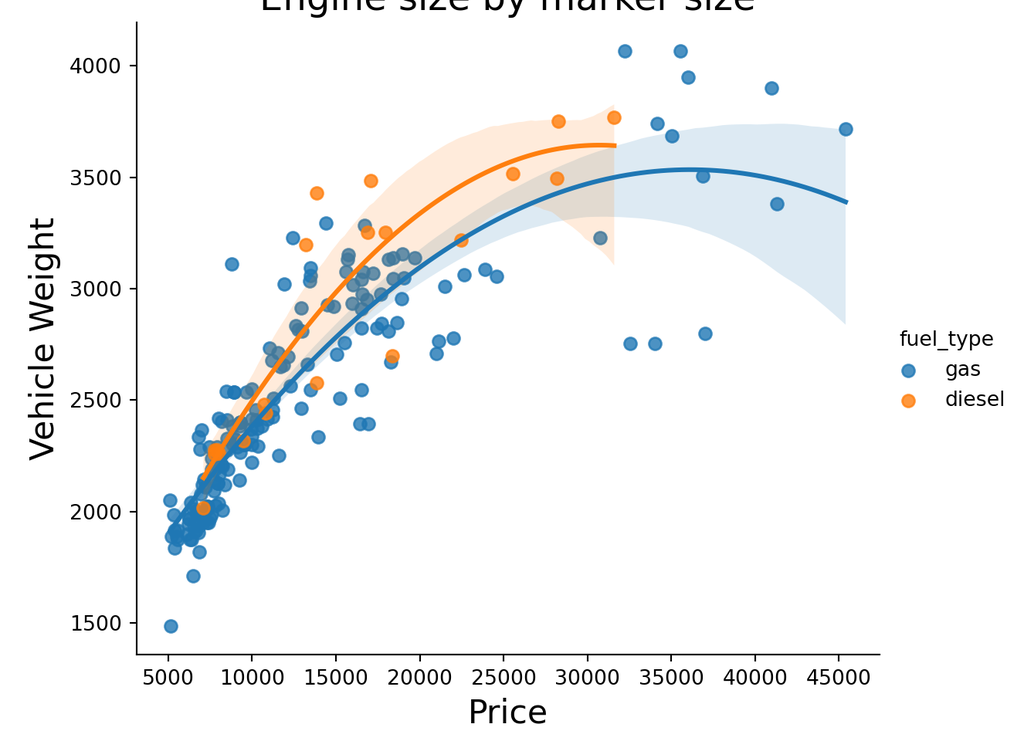

Second order polynomial fit

# Regression Line and Tramsformation Example

What are the distributions of these variables?

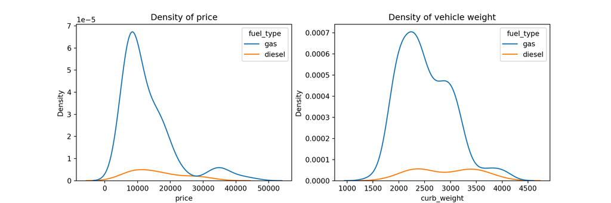

Notice the right skew of these distributions

# Regression Line and Tramsformation Example

Can transform distribution of variables

- Want distribution closer to Normal
- Many possible transformations
  - **Logarithmic:** Often good choice for variables with values $\gt 0$
  - **Square and square root:** Good choice for many physical systems
  - **Power transformation:** Find best fit transformation
  - **Fit to paramteric distribution:** Test if variable follows a known distribution

# Regression Line and Tramsformation Example

Can transform distribution of variables

- Multiple algorithms have been developed
  - Box-Cox, the first and still widely used for values $\gt 0$
  - Yeo-Johnson, works for values $\le 0$
- The Box-Cox transform fits a value for $\lambda$ that minimizes error with respect to a Normal distribution

$$\begin{split}x_i^{(\lambda)} =
\begin{cases}
\dfrac{x_i^\lambda - 1}{\lambda} & \text{if } \lambda \neq 0,
\\[8pt]
\ln{(x_i)} & \text{if } \lambda = 0,
\end{cases}\end{split}$$

- See the [Scikit-Learn Users’ Guide](https://scikit-learn.org/stable/modules/preprocessing.html#preprocessing-transformer) for more details

# Regression Line and Tramsformation Example

Transform the distributions

```python
pt = PowerTransformer(method='box-cox')
pt.fit(np.array(auto_price['price']).reshape(-1, 1))
auto_price['power_price'] = pt.transform(np.array(auto_price['price']).reshape(-1, 1))

fig, ax = plt.subplots(1,2,figsize=(12, 4))
ax[0]=sns.kdeplot(x = 'power_price',
                      hue = 'fuel_type',
                      data=auto_price,
                      ax=ax[1]);
ax[0].set_title('Density of power transformed price');
ax[0].set_xlabel('Transformed price');
ax[1]=sns.kdeplot(x = 'curb_weight',
                      hue = 'fuel_type',
                      data=auto_price,
                      ax=ax[1]);
ax[1].set(xscale="log");
ax[1].set_title('Density of log vehicle weight');
ax[1].set_xlabel('Log vehicle weight');
plt.show()
```

# Regression Line and Tramsformation Example

Transform the distributions

Distribution of logarithm of the curb weight

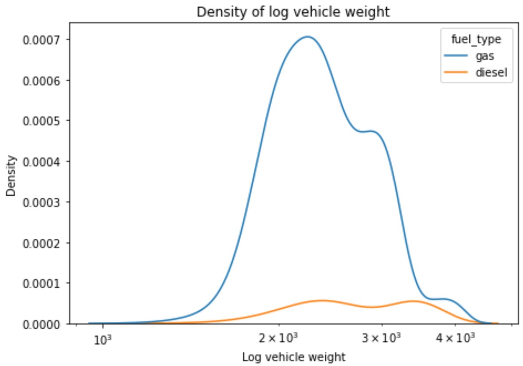

# Regression Line and Tramsformation Example

Transform the distributions

Distribution of power transformed price, $\lambda = -0.64$

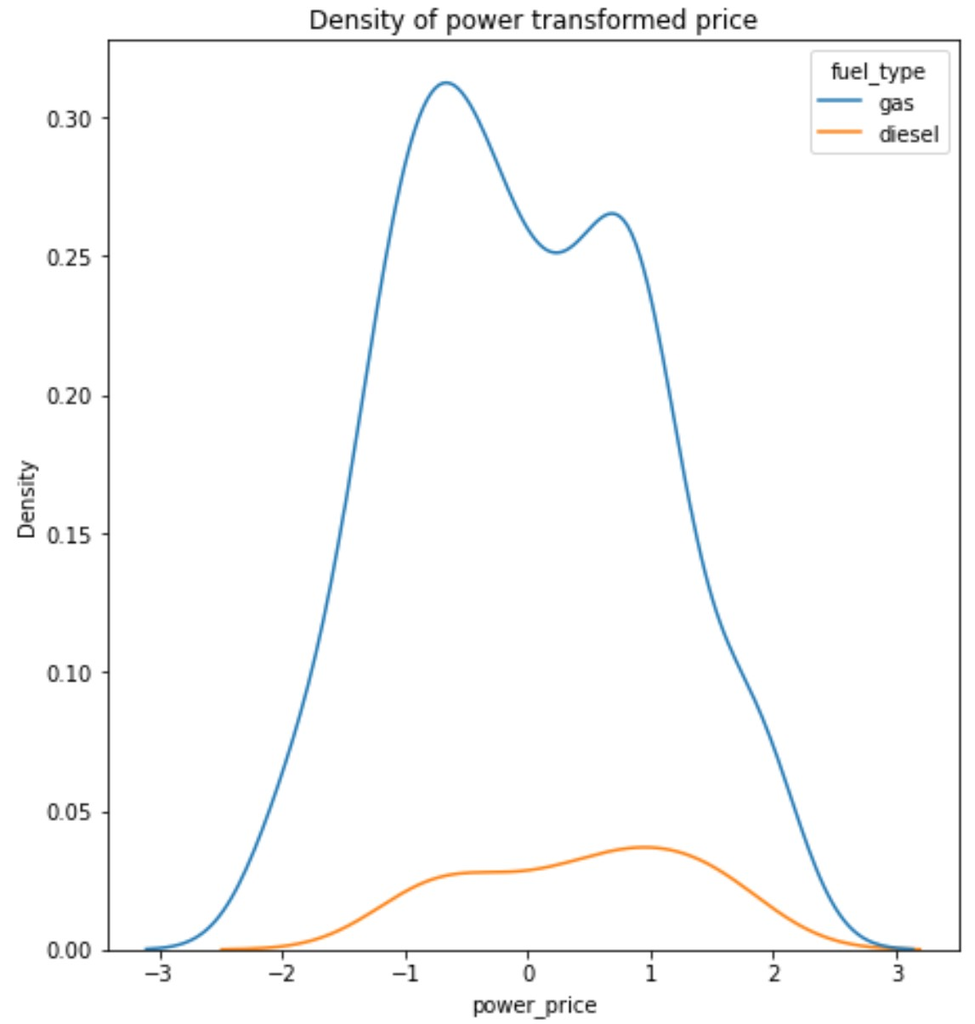

Transformed distribution has minimal skew!

# Regression Line and Tramsformation Example

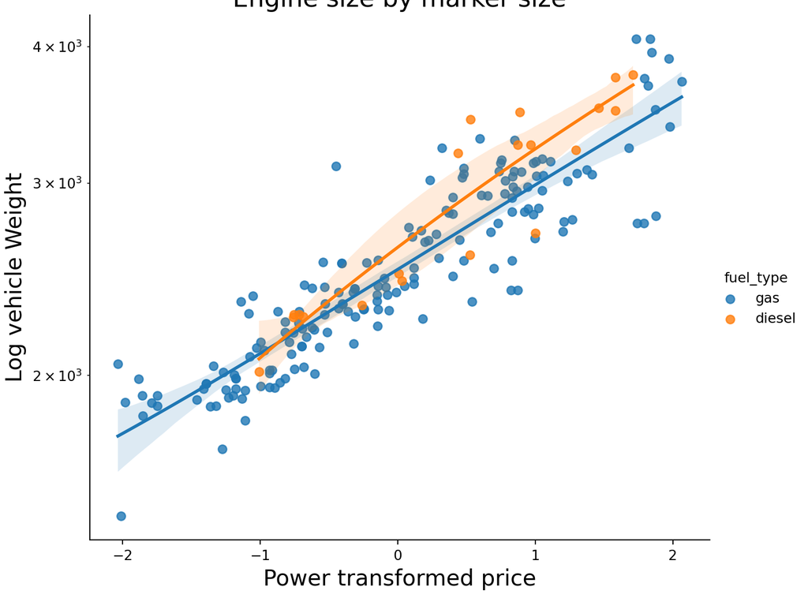

Second order polynomial fit

# Summary

We have explored these key points  
- Visualization is a powerful EDA method  
- Understand relationships in data  
- Communicate data scince insights

- Proper use of plot aesthetics enable projection of multiple dimensions of complex data onto the 2-dimensional plot surface.
- All plot aesthetics have limitations which must be understood to use them effectively
- The effectiveness of a plot aesthetic varies with the type and the application
- Regression lines help to focus viewer on trends
- Transformations to linear relationships can be informative